# Which AI model fits each task?

48 regressions — individual progress report

Nessim Betesh · IDS 3000

November 9, 2026

## What I did

I updated Jaime’s regressions for phase 2b. Each AI model has one binomial logistic regression fitted to votes with a winner. A question can have several features at once. The model estimates the chance of a win on a decisive vote given those features.

The descriptive fit below uses **77,843 decisive votes** from April through July, represented by two model-side rows per vote. There are 48 fitted models. As in Jaime’s original code, flagged review cases are excluded from the fit. The original data are unchanged.

## Response and predictors

The response is 1 for a win and 0 for a loss. These are the only predictors; all describe the question, before the AI writes an answer.

| Feature | Meaning |
| --- | --- |
| is_code | The question involves programming. |
| math | The question involves mathematics. |
| creative_writing | The question asks for creative writing. |
| instruction_following | The question contains specific instructions. |
| complexity | The question is complex. |
| creativity | The task needs creative thinking. |
| domain_knowledge | The task needs subject knowledge. |
| problem_solving | The task needs problem-solving steps. |
| real_world | The task has a practical, real-world use. |
| specificity | The task is specific and well defined. |
| technical_accuracy | The task needs technical accuracy. |

Response length, formatting, price and tokens are **not** predictors. The opponent is not a predictor in these separate regressions (group decision 5).

This is the actual regression specification:

```r
glm(y ~ is_code + math + creative_writing + instruction_following +
      complexity + creativity + domain_knowledge + problem_solving +
      real_world + specificity + technical_accuracy,
    family = binomial(), data = votes_for_one_model)
```

The main fit uses standard logistic regression. The half-point quasibinomial fit remains available as a sensitivity check. Ridge is optional and the descriptive results below use no penalty.

## The regressions: full R output

A positive `math` coefficient means a higher fitted win probability on math questions, holding the other features fixed. It is a change in log-odds, not a percentage-point change or a causal effect. For example, Gemini’s math coefficient is **0.205**. P-values below are nominal: the rows are not independent across models.

Open each example to see its **complete `summary()` output**, including coefficients, deviance and convergence information. The third example has the fewest votes in this descriptive fit.

**gemini-2.5-pro — 5,600 votes**

`summary(ajustes[[“gemini-2.5-pro”]])`

```
Call:
glm(formula = formula, family = familia, data = filas)

Coefficients:
                           Estimate Std. Error z value Pr(>|z|)
(Intercept)                0.654660   0.077310   8.468  < 2e-16 ***
is_codeTRUE               -0.201885   0.077703  -2.598 0.009372 **
mathTRUE                   0.205426   0.129282   1.589 0.112066
creative_writingTRUE       0.182180   0.122596   1.486 0.137274
instruction_followingTRUE -0.162973   0.090548  -1.800 0.071884 .
complexityTRUE             0.003184   0.077703   0.041 0.967313
creativityTRUE             0.200533   0.078803   2.545 0.010936 *
domain_knowledgeTRUE       0.428495   0.096893   4.422 9.76e-06 ***
problem_solvingTRUE        0.049577   0.090426   0.548 0.583512
real_worldTRUE             0.159950   0.086888   1.841 0.065639 .
specificityTRUE           -0.310740   0.090343  -3.440 0.000583 ***
technical_accuracyTRUE     0.108989   0.087820   1.241 0.214586
---
Signif. codes:  0 '***' 0.001 '**' 0.01 '*' 0.05 '.' 0.1 ' ' 1

(Dispersion parameter for binomial family taken to be 1)

    Null deviance: 6386.6  on 5599  degrees of freedom
Residual deviance: 6325.2  on 5588  degrees of freedom
AIC: 6349.2

Number of Fisher Scoring iterations: 4
```

**claude-opus-4-20250514 — 5,986 votes**

`summary(ajustes[[“claude-opus-4-20250514”]])`

```
Call:
glm(formula = formula, family = familia, data = filas)

Coefficients:
                          Estimate Std. Error z value Pr(>|z|)
(Intercept)               -0.20614    0.06869  -3.001  0.00269 **
is_codeTRUE                0.27428    0.06790   4.039 5.36e-05 ***
mathTRUE                   0.11411    0.10743   1.062  0.28814
creative_writingTRUE       0.31362    0.10160   3.087  0.00202 **
instruction_followingTRUE  0.24818    0.07850   3.161  0.00157 **
complexityTRUE             0.18037    0.06556   2.751  0.00594 **
creativityTRUE            -0.11547    0.06630  -1.742  0.08157 .
domain_knowledgeTRUE       0.02328    0.08300   0.280  0.77911
problem_solvingTRUE        0.09085    0.07614   1.193  0.23282
real_worldTRUE            -0.15675    0.07291  -2.150  0.03156 *
specificityTRUE            0.21623    0.07541   2.867  0.00414 **
technical_accuracyTRUE    -0.21527    0.07483  -2.877  0.00402 **
---
Signif. codes:  0 '***' 0.001 '**' 0.01 '*' 0.05 '.' 0.1 ' ' 1

(Dispersion parameter for binomial family taken to be 1)

    Null deviance: 8293.5  on 5985  degrees of freedom
Residual deviance: 8211.1  on 5974  degrees of freedom
AIC: 8235.1

Number of Fisher Scoring iterations: 4
```

**gemini-2.5-pro-preview-03-25 — 796 votes**

`summary(ajustes[[“gemini-2.5-pro-preview-03-25”]])`

```
Call:
glm(formula = formula, family = familia, data = filas)

Coefficients:
                           Estimate Std. Error z value Pr(>|z|)
(Intercept)               -0.053570   0.187063  -0.286  0.77459
is_codeTRUE               -0.285562   0.207933  -1.373  0.16965
mathTRUE                   0.084623   0.308408   0.274  0.78379
creative_writingTRUE       0.370941   0.311259   1.192  0.23336
instruction_followingTRUE  0.218887   0.229586   0.953  0.34039
complexityTRUE             0.328778   0.200516   1.640  0.10108
creativityTRUE             0.495718   0.212349   2.334  0.01957 *
domain_knowledgeTRUE       0.701769   0.244693   2.868  0.00413 **
problem_solvingTRUE        0.115975   0.225399   0.515  0.60688
real_worldTRUE            -0.249405   0.222175  -1.123  0.26162
specificityTRUE            0.006143   0.239886   0.026  0.97957
technical_accuracyTRUE    -0.166484   0.236893  -0.703  0.48219
---
Signif. codes:  0 '***' 0.001 '**' 0.01 '*' 0.05 '.' 0.1 ' ' 1

(Dispersion parameter for binomial family taken to be 1)

    Null deviance: 1007.22  on 795  degrees of freedom
Residual deviance:  970.53  on 784  degrees of freedom
AIC: 994.53

Number of Fisher Scoring iterations: 4
```

## Feature effects for all 48 models

Blue means a higher fitted win probability when a feature is present; red means a lower probability. These are **log-odds coefficients**, with the other features held fixed. The intercept is omitted from this chart. Full values, including all intercepts, are in `R/resultados/coeficientes_por_modelo.csv`.

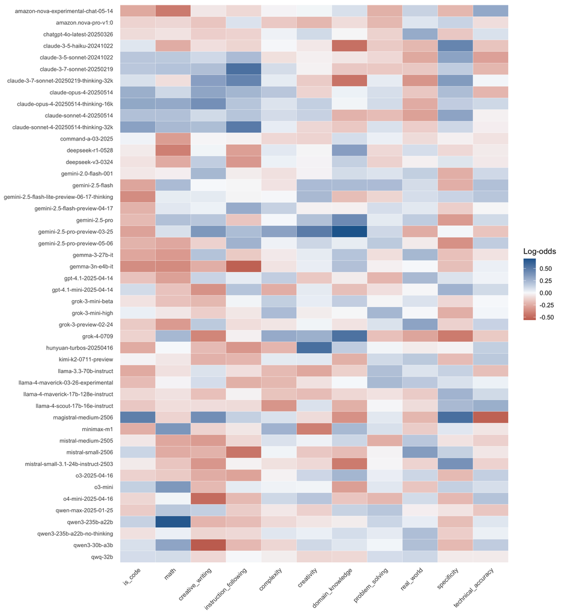

Descriptive fit with decisive April–July votes and no ridge.

## Does it predict unseen votes?

The descriptive fit above uses all months. The test below uses a separate fit. The table below comes directly from **Mark’s saved evaluation**. Mark fits on April–June only and evaluates decisive July votes where both models were seen in train. All three methods in this table use decisive votes for training.

| Method | July votes | Correct | Accuracy (%) | Log-loss (lower is better) |
| --- | --- | --- | --- | --- |
| General Bradley–Terry ranking | 20416 | 13164 | 64.5 | 0.6340 |
| General win rate | 20416 | 13162 | 64.5 | 0.6340 |
| Separate binomial regressions | 20416 | 13303 | 65.2 | 0.6298 |

The separate regressions gain **0.68 percentage points** in accuracy over the general Bradley–Terry ranking. They also have lower log-loss on this July test.

### Sensitivity check

With the optional quasibinomial fit, ties and votes where both answers were bad each receive half a point in training. On the same decisive July votes, this version achieved **65.1%** accuracy and **0.6321** log-loss.

## Top 3 by task

`top3()` averages fitted win probabilities over **real questions** with each feature, allowing the other features to vary. The descriptive fit uses decisive votes from all four months. Only models with **at least 100 votes in July** can be recommended. Versions remain separate. These scores rank the models for each task. Each model has its own fitted probability.

| Task | Rank | Model | Mean fitted win probability |
| --- | --- | --- | --- |
| Code | 1 | gemini-2.5-pro | 0.722 |
| Code | 2 | grok-4-0709 | 0.651 |
| Code | 3 | o3-2025-04-16 | 0.650 |
| Math | 1 | gemini-2.5-pro | 0.769 |
| Math | 2 | grok-4-0709 | 0.735 |
| Math | 3 | gemini-2.5-flash | 0.675 |
| Creative writing | 1 | gemini-2.5-pro | 0.757 |
| Creative writing | 2 | grok-3-preview-02-24 | 0.663 |
| Creative writing | 3 | grok-4-0709 | 0.639 |
| Instructions | 1 | gemini-2.5-pro | 0.731 |
| Instructions | 2 | grok-4-0709 | 0.671 |
| Instructions | 3 | gemini-2.5-flash | 0.649 |
| Code + math | 1 | gemini-2.5-pro | 0.748 |
| Code + math | 2 | grok-4-0709 | 0.705 |
| Code + math | 3 | qwen3-235b-a22b | 0.689 |
| All questions | 1 | gemini-2.5-pro | 0.742 |
| All questions | 2 | grok-4-0709 | 0.688 |
| All questions | 3 | o3-2025-04-16 | 0.658 |

An optional budget filters **output price per million tokens**, not total cost per answer. Unknown prices are excluded only when a budget is supplied. The budget example uses Marco’s v2 price table, as required by this task. List prices do not measure the full cost of a reasoning response. For example:

```r
top3("math", ajustes, precio_max = 2)
```

## Limits and next step

- Each vote contributes two model-side rows; the separate fits are dependent.
- The main test is one time split, April–June versus July.
- Four models appear only in July and cannot be tested with that training set.

The combined Bradley–Terry model is a separate next task. It will use one row per vote and account directly for the opponent. This report does not include it.

*Prepared by Nessim Betesh with assistance from ChatGPT/Codex. Existing model code by Jaime and held-out evaluation by Mark. AI-generated code and text were checked against the repository’s data, saved outputs and rules.*